# Самостоятельная работа. Интеракция и сравнение моделей

Задание: Повторите анализ, который мы делали в классе, но вместо пола ученика используйте тип населенного пункта (переменная city):

1. Постройте график связи баллов по математике и шкалы буллинга в зависимости от типа населенного пункта, в котором проживает учащийся
2. Проверьте модели обычной линейной регрессии и проинтерпретируйте их
3. Постройте две многоуровневых модели (выберите две любые и обоснуйте их) и интерпретируйте результаты каждой.
4. Сравните обе модели. Какая лучше подходит данным?

**Загрузка пакетов и данных**

```r
library(rio)
library(tidyverse)
library(skimr)
library(sjPlot)
library(lme4)
library(lmerTest)
library(lattice)
library(merTools)
```

```r
timss15 <- import("timss15_math.csv")

timss15$area <- as.factor(timss15$area)
timss15$itsex <- as.factor(timss15$itsex)
timss15$like_math <- as.factor(timss15$like_math)
timss15$par_edu <- as.factor(timss15$par_edu)
timss15$bsdgsb <- as.factor(timss15$bsdgsb)
timss15$bull_scl <- as.numeric(timss15$bull_scl)
timss15$city <- fct_collapse(timss15$area, urban = c("Urban, densely populated", "Medium size city or large town"), other = c("Suburban, on fringe of urban area", "Remote rural", "Small town or village"))

timss15$math_achiev_sd <- (timss15$math_achiev - mean(timss15$math_achiev)) / sd(timss15$math_achiev)
timss15$bull_scl_sd <- (timss15$bull_scl - mean(timss15$bull_scl, na.rm = T)) / sd(timss15$bull_scl, na.rm = T)

skim(timss15)
```

```
## Skim summary statistics
##  n obs: 4765
##  n variables: 22
```

```
##
## Variable type: character
##       variable missing complete    n min max empty n_unique
##  conf_math_scl       0     4765 4765   6  18     0      131
##
## Variable type: factor
##   variable missing complete    n n_unique
##       area       0     4765 4765        5
##     bsdgsb       0     4765 4765        4
##       city       0     4765 4765        2
##      itsex       0     4765 4765        2
##  like_math       0     4765 4765        3
##    par_edu       0     4765 4765        4
##                                top_counts ordered
##  Urb: 1554, Med: 1394, Sub: 692, Rem: 640   FALSE
##    Alm: 3126, Abo: 1432, Abo: 200, Omi: 7   FALSE
##               urb: 2948, oth: 1817, NA: 0   FALSE
##               Mal: 2474, Fem: 2291, NA: 0   FALSE
##     Lik: 2295, Do : 1575, Ver: 895, NA: 0   FALSE
##   No : 2164, Hig: 1975, Don: 601, Unk: 25   FALSE
##
## Variable type: integer
##   variable missing complete    n     mean       sd    p0    p25   p50
##    idclass       0     4765 4765 10366.12  5992.36   102   5301 10401
##   idschool       0     4765 4765   103.64    59.92     1     53   104
##     idstud       0     4765 4765 1e+06    6e+05    10201 530109 1e+06
##  teach_exp     107     4658 4765    23.15    11.17     1     15    25
##      p75  p100     hist
##    15702 20401 ▇▆▇▇▇▇▇▇
##      157   204 ▇▆▇▇▇▇▇▇
##  1570212 2e+06 ▇▆▇▇▇▇▇▇
##       32    50 ▅▃▆▆▇▇▃▁
##
## Variable type: logical
##      variable missing complete    n mean count
##  conf_sci_scl    4765        0 4765  NaN  4765
##  like_sci_scl    4765        0 4765  NaN  4765
##
## Variable type: numeric
##        variable missing complete    n      mean     sd     p0    p25
##        bull_scl       7     4758 4765  10.07      1.79   2.47   8.78
##     bull_scl_sd       7     4758 4765  -4.8e-16   1     -4.26  -0.72
##   like_math_scl       0     4765 4765  10.06      1.56   4.97   9.13
##     math_achiev       0     4765 4765 538.44     78.54 298.47 483.74
##  math_achiev_sd       0     4765 4765   1.8e-16   1     -3.06  -0.7
##          matwgt       0     4765 4765 258.99    146.59  59.23 189.29
##      sci_achiev       0     4765 4765 545.02     72.39 305.1  497.3
##          st_age       0     4765 4765  14.76      0.42  13.25  14.5
##          totwgt       0     4765 4765 263.02    155.43  77.53 190.34
##      p50    p75    p100     hist
##    9.74   11.01   12.78 ▁▁▁▂▆▇▇▇
##   -0.19    0.52    1.52 ▁▁▁▂▆▇▇▇
##    9.87   10.92   13.98 ▁▁▂▆▇▃▂▁
##  541.53  595.5   761.34 ▁▂▅▇▇▆▂▁
##    0.039   0.73    2.84 ▁▂▅▇▇▆▂▁
##  234.12  270.73 1118.35 ▃▇▁▁▁▁▁▁
##  548.97  594.72  774.97 ▁▁▃▆▇▅▁▁
##   14.75   15      17.67 ▁▂▇▆▁▁▁▁
##  234.36  270.73 1118.35 ▅▇▁▁▁▁▁▁
```

# 1 Постройте график связи баллов по математике и шкалы буллинга в зависимости от типа населенного пункта, в котором проживает учащийся

Оценка нелиней связи:

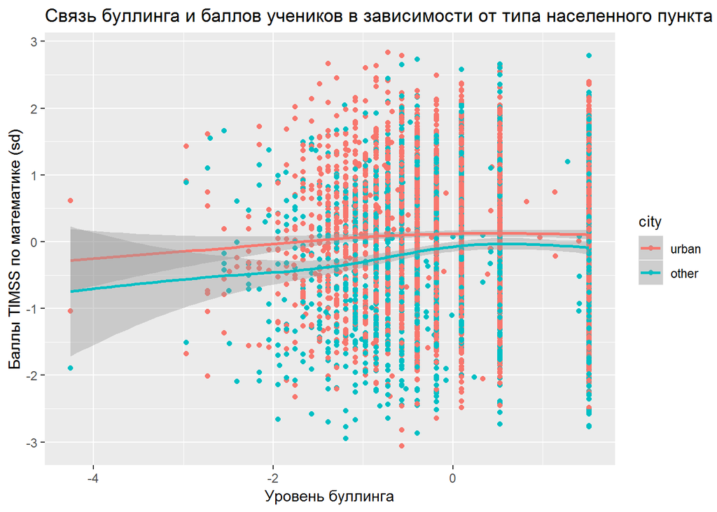

```r
  ggplot(data = timss15, aes(x = bull_scl_sd, y = math_achiev_sd, col = city)) +
  geom_point() +
  geom_smooth() +
  labs(x = 'Уровень буллинга', y = 'Баллы TIMSS по математике (sd)', title = 'Связь буллинга и баллов учеников в зависимости от типа населенного пункта')
```

Оценка линейной связи:

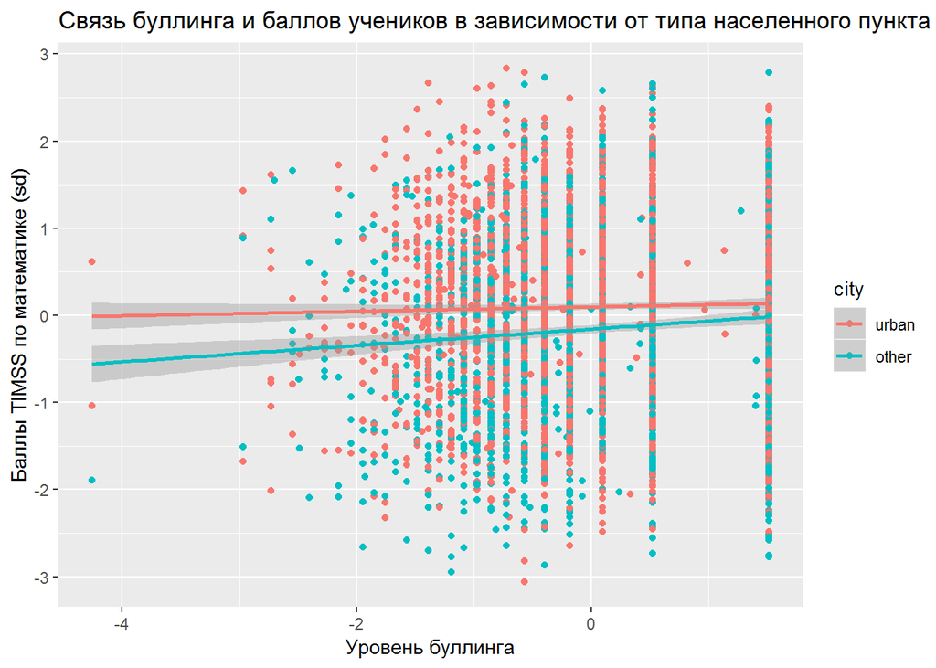

```r
  ggplot(data = timss15, aes(x = bull_scl_sd, y = math_achiev_sd, col = city)) +
  geom_point() +
  geom_smooth(method = "lm") +
  labs(x = 'Уровень буллинга', y = 'Баллы TIMSS по математике (sd)', title = 'Связь буллинга и баллов учеников в зависимости от типа населенного пункта')
```

В целом баллы TIMSS по математике выше у учеников, проживающих в городах. Связь уровня буллинга и результатов по математике положительная и более ярко выражена для учащихся, проживающих не в городах.

# 2 Проверьте модели обычной линейной регрессии и проинтерпретируйте их

```r
lm_1 <- lm(data = timss15, math_achiev_sd ~ bull_scl_sd, weight = matwgt)
summary (lm_1)
```

```
##
## Call:
## lm(formula = math_achiev_sd ~ bull_scl_sd, data = timss15, weights = matwgt)
##
## Weighted Residuals:
##     Min      1Q  Median      3Q     Max
## -66.371 -10.391   0.733  10.610  66.290
##
## Coefficients:
##              Estimate Std. Error t value Pr(>|t|)
## (Intercept) -0.003792   0.014556  -0.261 0.794481
## bull_scl_sd  0.055921   0.014566   3.839 0.000125 ***
## ---
## Signif. codes:  0 '***' 0.001 '**' 0.01 '*' 0.05 '.' 0.1 ' ' 1
##
## Residual standard error: 16.15 on 4756 degrees of freedom
##   (7 observations deleted due to missingness)
## Multiple R-squared:  0.003089,   Adjusted R-squared:  0.00288
## F-statistic: 14.74 on 1 and 4756 DF,  p-value: 0.0001251
```

```r
lm_2 <- lm(data = timss15, math_achiev_sd ~ city, weight = matwgt)
summary (lm_2)
```

```
##
## Call:
## lm(formula = math_achiev_sd ~ city, data = timss15, weights = matwgt)
##
## Weighted Residuals:
##     Min      1Q  Median      3Q     Max
## -69.207 -10.596   0.291  10.209  68.778
##
## Coefficients:
##             Estimate Std. Error t value Pr(>|t|)
## (Intercept)  0.09771    0.01938   5.042 4.79e-07 ***
## cityother   -0.23034    0.02916  -7.900 3.43e-15 ***
## ---
## Signif. codes:  0 '***' 0.001 '**' 0.01 '*' 0.05 '.' 0.1 ' ' 1
##
## Residual standard error: 16.09 on 4763 degrees of freedom
## Multiple R-squared:  0.01293,    Adjusted R-squared:  0.01273
## F-statistic: 62.41 on 1 and 4763 DF,  p-value: 3.434e-15
```

```r
lm_3 <- lm(data = timss15, math_achiev_sd ~ bull_scl_sd + city, weight = matwgt)
summary (lm_3)
```

```
##
## Call:
## lm(formula = math_achiev_sd ~ bull_scl_sd + city, data = timss15,
##     weights = matwgt)
##
## Weighted Residuals:
##     Min      1Q  Median      3Q     Max
## -69.420 -10.478   0.223  10.115  70.780
##
## Coefficients:
##             Estimate Std. Error t value Pr(>|t|)
## (Intercept)  0.09933    0.01935   5.134 2.95e-07 ***
## bull_scl_sd  0.05964    0.01448   4.120 3.86e-05 ***
## cityother   -0.23375    0.02913  -8.024 1.28e-15 ***
## ---
## Signif. codes:  0 '***' 0.001 '**' 0.01 '*' 0.05 '.' 0.1 ' ' 1
##
## Residual standard error: 16.05 on 4755 degrees of freedom
##   (7 observations deleted due to missingness)
## Multiple R-squared:  0.01641,    Adjusted R-squared:  0.01599
## F-statistic: 39.66 on 2 and 4755 DF,  p-value: < 2.2e-16
```

Шкала буллинга положительно, но слабо связана с баллом TIMSS: при увеличении шкалы на одно стандартное отклонение баллы TIMSS уеличиваются на 0,06 стандартного отклонения, модель объясняет менее 1 процента дисперсии. Учащиеся, проживающие не в гродах, в среднем получили на 0,23 стандартного отклонения ниже, чем проживающие в городах; модель объясняет 1,2% дисперсии. При включении в модель обеих переменныхпроцент объясненной дисперсии возрастает до 1,5, а сами коэффициенты практически не меняются.

```r
lm_int <- lm(data = timss15, math_achiev_sd ~ bull_scl_sd * city, weight = matwgt)
summary (lm_int)
```

```
##
## Call:
## lm(formula = math_achiev_sd ~ bull_scl_sd * city, data = timss15,
##     weights = matwgt)
##
## Weighted Residuals:
##    Min     1Q Median     3Q    Max
## -69.30 -10.55   0.25  10.15  72.29
##
## Coefficients:
##                       Estimate Std. Error t value Pr(>|t|)
## (Intercept)            0.09878    0.01933   5.109 3.36e-07 ***
## bull_scl_sd            0.02339    0.01952   1.198  0.23081
## cityother             -0.23539    0.02912  -8.084 7.89e-16 ***
## bull_scl_sd:cityother  0.08045    0.02908   2.767  0.00568 **
## ---
## Signif. codes:  0 '***' 0.001 '**' 0.01 '*' 0.05 '.' 0.1 ' ' 1
##
## Residual standard error: 16.04 on 4754 degrees of freedom
##   (7 observations deleted due to missingness)
## Multiple R-squared:  0.01799,    Adjusted R-squared:  0.01737
## F-statistic: 29.03 on 3 and 4754 DF,  p-value: < 2.2e-16
```

при включении в модель интеракции этих дву переменных связь между уровнем буллинга самим по себе и баллом TIMSS перестает быть значимой. Однако коэффициент для интеракции значим на уровне 0,01: дл учащихся, проживающих не в городах, увеличение уровня буллинга на 1 ст. откл. приводит к росту балла TIMSS на 0,08 ст.откл. больше, чем для городских учащихся.

Визуализируем полученные результаты.

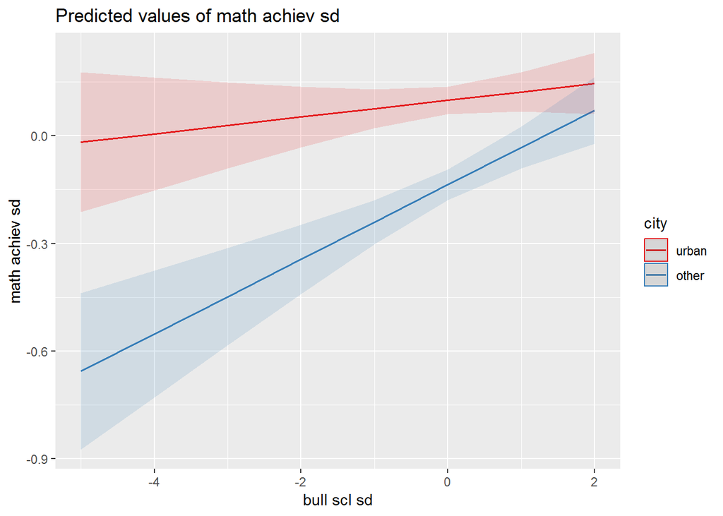

```r
plot_model(lm_int, type = "int")
```

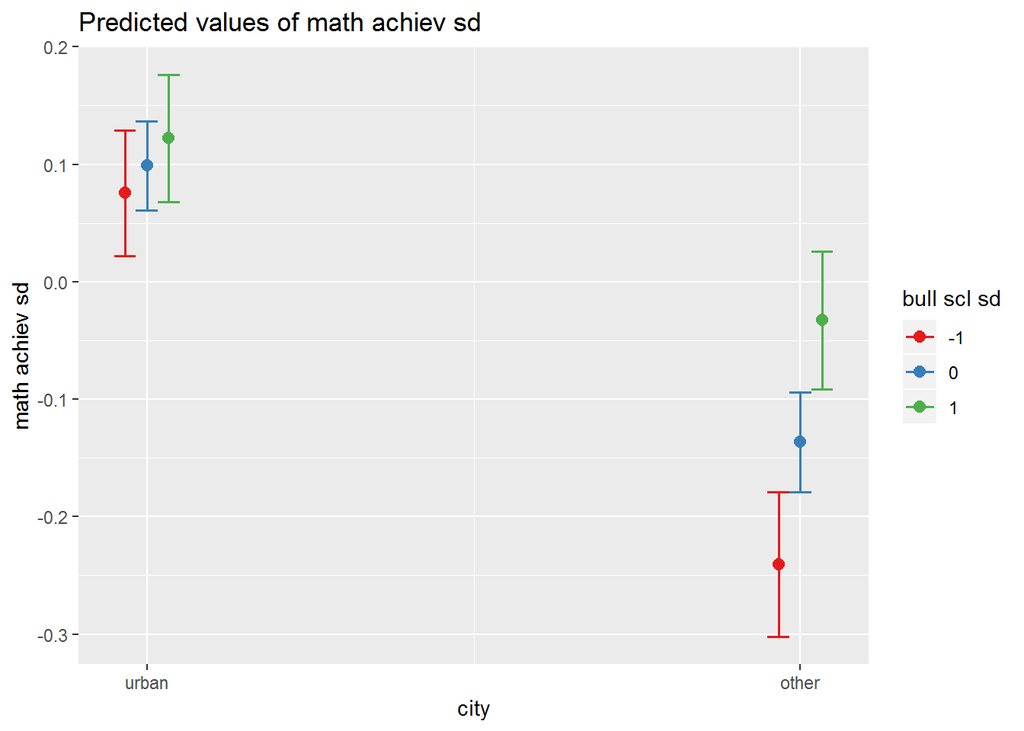

```r
plot_model(lm_int, type = "pred", terms = c("city", "bull_scl_sd [-1, 0, 1]"))
```

# 3 Постройте две многоуровневых модели (выберите две любые и обоснуйте их) и интерпретируйте результаты каждой.

1. Модель random intercept

```r
hlm_1 <- lmer(data = timss15, math_achiev_sd  ~  bull_scl_sd * city + (1 | idclass), weight = matwgt)
summary(hlm_1)
```

```
## Linear mixed model fit by REML. t-tests use Satterthwaite's method [
## lmerModLmerTest]
## Formula: math_achiev_sd ~ bull_scl_sd * city + (1 | idclass)
##    Data: timss15
## Weights: matwgt
##
## REML criterion at convergence: 12227.4
##
## Scaled residuals:
##     Min      1Q  Median      3Q     Max
## -4.6507 -0.6107  0.0100  0.6325  4.3814
##
## Random effects:
##  Groups   Name        Variance Std.Dev.
##  idclass  (Intercept)   0.3904  0.6249
##  Residual             155.6456 12.4758
## Number of obs: 4758, groups:  idclass, 221
##
## Fixed effects:
##                         Estimate Std. Error         df t value Pr(>|t|)
## (Intercept)              0.08538    0.05871  219.07262   1.454   0.1473
## bull_scl_sd              0.01214    0.01593 4597.68534   0.762   0.4458
## cityother               -0.19842    0.08816  218.98928  -2.251   0.0254 *
## bull_scl_sd:cityother    0.02476    0.02416 4623.94674   1.025   0.3056
## ---
## Signif. codes:  0 '***' 0.001 '**' 0.01 '*' 0.05 '.' 0.1 ' ' 1
##
## Correlation of Fixed Effects:
##             (Intr) bll_s_ ctythr
## bull_scl_sd  0.001
## cityother   -0.666 -0.001
## bll_scl_sd: -0.001 -0.659 -0.009
```

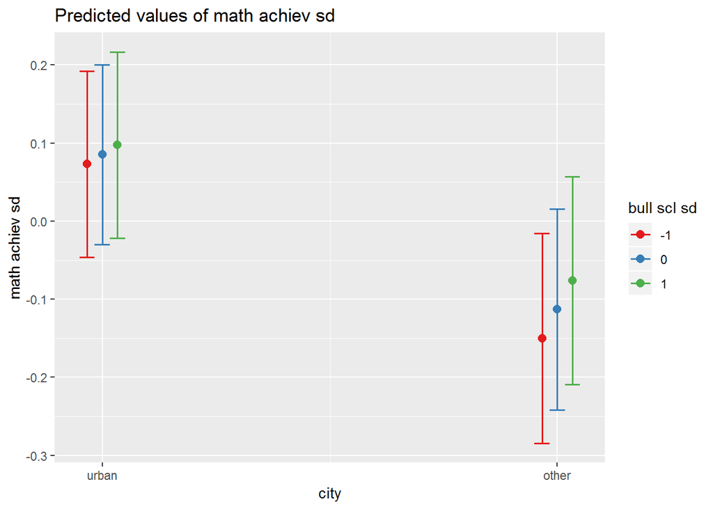

```r
plot_model(hlm_1, type = "pred", terms = c("city", "bull_scl_sd [-1, 0, 1]"))
```

При использовании многоуровневой модели значимым остается только один коэффициент - для переменной Тип населенного пункта. Коэффициент интеракции, как видно в таблице и на графике, не значим. Важно отметить, что интерцепт варьируется очень сильно от группы к группе.

2. Модель random intercept, random slope uncorrelated

```r
hlm_2 <- lmer(data = timss15, math_achiev_sd  ~  bull_scl_sd * city + (bull_scl_sd || idclass), weight = matwgt)
summary(hlm_2)
```

```
## Linear mixed model fit by REML. t-tests use Satterthwaite's method [
## lmerModLmerTest]
## Formula: math_achiev_sd ~ bull_scl_sd * city + (bull_scl_sd || idclass)
##    Data: timss15
## Weights: matwgt
##
## REML criterion at convergence: 12222.8
##
## Scaled residuals:
##     Min      1Q  Median      3Q     Max
## -4.6904 -0.6118  0.0106  0.6299  4.3503
##
## Random effects:
##  Groups    Name        Variance  Std.Dev.
##  idclass   (Intercept) 3.896e-01  0.6242
##  idclass.1 bull_scl_sd 5.565e-03  0.0746
##  Residual              1.543e+02 12.4225
## Number of obs: 4758, groups:  idclass, 221
##
## Fixed effects:
##                        Estimate Std. Error        df t value Pr(>|t|)
## (Intercept)             0.08573    0.05866 218.65379   1.461   0.1453
## bull_scl_sd             0.01036    0.01765 204.68939   0.587   0.5577
## cityother              -0.19816    0.08811 218.79650  -2.249   0.0255 *
## bull_scl_sd:cityother   0.02503    0.02658 222.57819   0.941   0.3475
## ---
## Signif. codes:  0 '***' 0.001 '**' 0.01 '*' 0.05 '.' 0.1 ' ' 1
##
## Correlation of Fixed Effects:
##             (Intr) bll_s_ ctythr
## bull_scl_sd  0.002
## cityother   -0.666 -0.001
## bll_scl_sd: -0.001 -0.664 -0.009
```

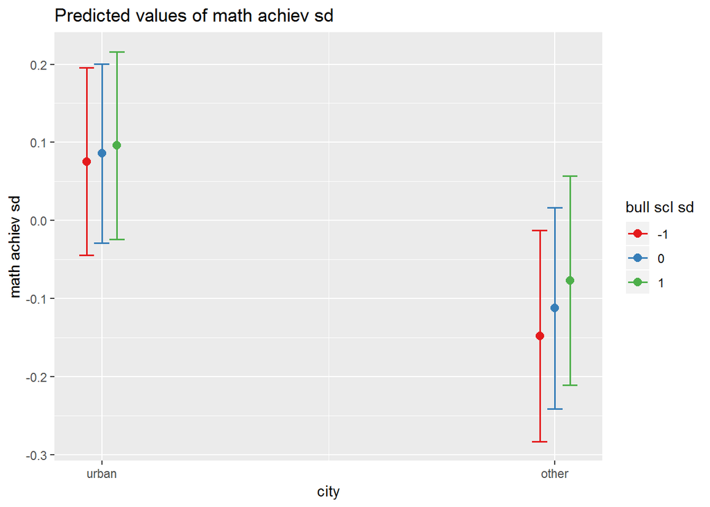

```r
plot_model(hlm_2, type = "pred", terms = c("city", "bull_scl_sd [-1, 0, 1]"))
```

# 4 Сравните обе модели. Какая лучше подходит данным?

```r
anova(hlm_1, hlm_2)
```

```
## refitting model(s) with ML (instead of REML)
```

```
## Data: timss15
## Models:
## hlm_1: math_achiev_sd ~ bull_scl_sd * city + (1 | idclass)
## hlm_2: math_achiev_sd ~ bull_scl_sd * city + (bull_scl_sd || idclass)
##       Df   AIC   BIC  logLik deviance  Chisq Chi Df Pr(>Chisq)
## hlm_1  6 12219 12258 -6103.7    12207
## hlm_2  7 12217 12262 -6101.6    12203 4.2003      1    0.04042 *
## ---
## Signif. codes:  0 '***' 0.001 '**' 0.01 '*' 0.05 '.' 0.1 ' ' 1
```

И все же вторая модель чуть лучше первой - разница в deviance значима на уровне 0,05. В дальнейших исследованиях будем использовать её.